# Préparation de la base DVF

Author

Claude Grasland

On rappelle ici les modes d’acquisition de la pase DVF à l’aide d’une API et les étapes de nettoyage de celles-ci avant utilisations à l’aide d’une variante du programme proposé par B. Merickskay & Demoraes.

- **Mericskay, B., & Demoraes, F. (2022)**. Préparer et analyser les données de” Demandes de valeurs foncières” en open data: proposition d’une méthodologie reproductible. *Cybergeo: European Journal of Geography.*

# PRÉPARATION DES DONNÉES DVF OPENDATA

Cette première partie du script a comme objectif de préparer les données DVF en opendata (apurement, filtrage, agrégation,…) avant de commencer les analyses.

Seul le package `tidyverse` dédié à la manipulation de données est nécessaire.

```r
library(tidyverse)
library(jsonlite)
```

## Chargement du jeu de données

On utilise ici une API qui exrait une commune de la base des valeurs foncières géolocalisées.

```r
## CODE INSEE DE LA COMMUNE
mycom <- "94071"


## Choix du lien
link<-paste0("https://public.opendatasoft.com/api/explore/v2.1/catalog/datasets/buildingref-france-demande-de-valeurs-foncieres-geolocalisee-millesime/exports/json?lang=fr&refine=com_code%3A%22",mycom,"%22&timezone=Europe%2FParis")


## Récumération comme tableau
DVF<-fromJSON(link)
```

## Filtre et nettoyage des données

### Etape1 -> Sélection des mutations de type “Ventes” de “Maison” et “Appartement’

```r
etape1 <- DVF %>% filter(nature_mutation == "Vente")
etape1bis <- etape1 %>% filter(type_local == "Maison" | type_local == "Appartement")
```

### Etape2 -> Sélection et renommage des variables

```r
etape2 <- etape1bis %>% select(id = id_mutation,
                               disposition = numero_disposition,
                               parcelle = id_parcelle,
                               date = date_mutation,
                               nature = nature_mutation,
                               codecommune = com_code ,
                               departement = dep_code,
                               type = type_local,
                               surface = surface_reelle_bati,
                               piece = nombre_pieces_principales,
                               prix = valeur_fonciere,
                               latitude,
                               longitude)
```

### Etape3 -> Remplacement des cellules vides par des NA et suppression des NA

```r
etape2[etape2 == ""] <- NA
etape3 <- etape2 %>% na.omit()
```

## Suppression des doublons et des mutations multiventes

### Etape4 -> Sélections des mutations simples

#### Regrouper les transactions selon l’id, la surface et le prix de vente

```r
# pour vérifier s'il y a des multiventes (lignes partageant le même id, le même prix et la même surface)
table(duplicated(paste0(etape3$id, etape3$prix, etape3$surface))) # Le résultat est un tableau indiquant combien de lignes sont des multiventes (TRUE) et combien ne le sont pas (FALSE).
```

```
FALSE  TRUE
 3107   165
```

```r
# Création d'un tableau sans multiventes
unique <- etape3 %>% distinct(id, prix, surface) # Si plusieurs lignes ont la même valeur pour id, prix et surface, seule la première occurrence est conservée.

#  Pour savoir, pour chaque id, combien de combinaisons uniques de prix et surface existent dans le tableau sans multiventes.
nbunique <- unique %>% group_by(id) %>% summarise(nb = n())
```

#### Suppression des doublons et des mutations multiventes

```r
# Filtrage du tableau initial pour ne garder que les ventes simples
etape4 <- nbunique %>% filter(nb == 1)
```

### Etape5 -> Jointure attributaire pour récupérer les informations des mutations dans la table sans doublon

```r
merge <- cbind(etape4, etape3[match(etape4$id, etape3$id), -1, drop = TRUE]) # plus rapide que merge() et permet de garder seulement les lignes de etape4
etape5 <- merge %>% select(id, date, type, nature, codecommune, prix, surface, piece, latitude, longitude)
```

### Modification du format des colonnes (nombres entiers -> nombres réels)

```r
etape5$prix <- as.numeric(etape5$prix)
etape5$surface <- as.numeric(etape5$surface)
etape5$piece <- as.numeric(etape5$piece)
```

## Suppression des valeurs aberrantes

### Fixer un seuil minimal des prix (percentiles)

```r
quantile(etape5$prix, 0.01)
```

```
   1%
70000
```

### Fixer un seuil maximal des prix (histogramme)

```r
options(scipen=999)
summary(etape5$prix)
```

```
   Min. 1st Qu.  Median    Mean 3rd Qu.    Max.
      1  185000  292000  329574  431000 3200000
```

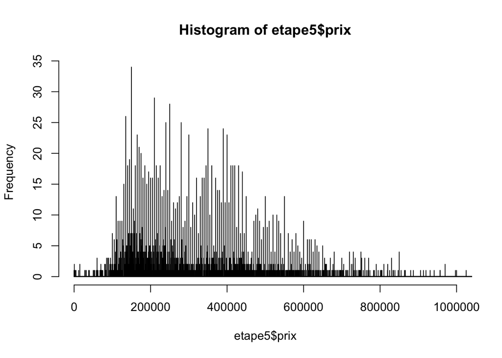

```r
hist(etape5$prix, breaks = 50000, xlim = c(0,1000000))
```

### Créer deux jeux de données (maisons / appartements)

```r
Maisons <- etape5 %>% filter(type == 'Maison')
Appartements <- etape5 %>% filter (type == 'Appartement')
```

### Fixer un seuil maximal des surfaces (histogramme)

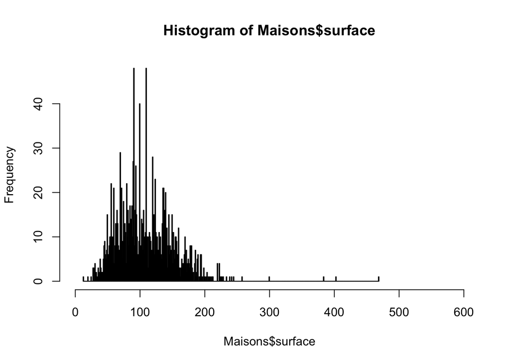

```r
hist(Maisons$surface, nclass = 500, xlim = c(0,600))
```

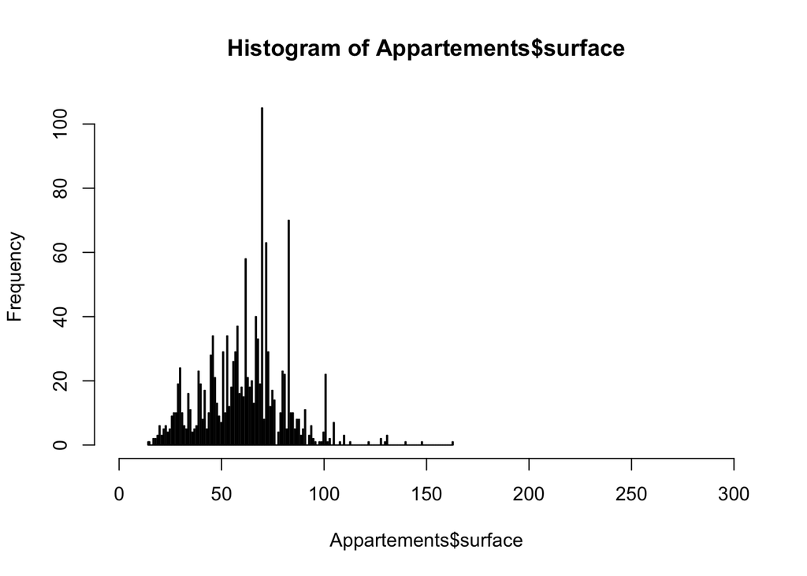

```r
hist(Appartements$surface, nclass = 500, xlim = c(0,300))
```

### Etape 6 -> Sélection des bornes de prix et de surface

```r
etape6 <- etape5 %>% filter(between(prix, 15000, 5000000)) %>%
                     filter(case_when(type == 'Appartement' ~ between(surface, 10, 200)) |
                            case_when(type == 'Maison' ~ between(surface, 10, 350)))
```

## Calcul du prix au m² et exclusion des valeurs extrêmes et aberrantes

### Etape7 -> Calcul de la variable prix/m²

```r
etape7 <- etape6 %>% mutate(prixm2 = prix/surface)
```

### Etape8 -> Sélection des bornes de prix au m²

#### Fixer un seuil minimal des prix au m² (percentile)

```r
quantile(etape7$prixm2, 0.01)
```

```
      1%
1177.126
```

#### Fixer un seuil maximal des prix au m² (histogramme)

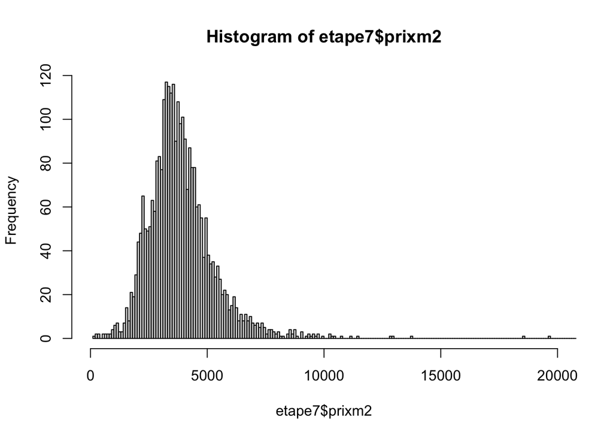

```r
hist(etape7$prixm2, breaks = 1000, xlim = c(0,20000))
```

#### Filtres des valeurs

```r
etape8 <- etape7 %>% filter(between(prixm2, 330, 20000))
```

#### Extraction de l’année à partir de la date

```r
etape8 <- etape8 %>% mutate(annee = substr(etape8$date, 1, 4))
```

#### Arrondir les valeurs

```r
etape8$prix <- round(etape8$prix)
etape8$prixm2 <- round(etape8$prixm2)
```

### Etape12 -> Structuration du jeu de données final

```r
DVFOK <- etape8 %>% select(id, date, annee, type, prix, surface, prixm2, codecommune,  latitude, longitude)
```

### Exporter le jeu de données final en csv

```r
write.csv(DVFOK, 'DVFOK.csv', quote = FALSE, row.names = FALSE)
```

### Diagnostic des types de mutations

#### Calcul du nombre de mutations

```r
length(unique(etape3$id))
```

```
[1] 2997
```

#### Nombre de mutations multiventes

```r
MutationsComplexes <- nbunique %>% filter(nb > 1)
length(unique(MutationsComplexes$id))
```

```
[1] 76
```

#### Nombre de mutations monoventes/monolignes

```r
uniquesimple <- etape3 %>% group_by(id) %>% summarise(prix = first(prix), surface = first(surface), nb = n())
nbtransactionssimplemonoligne <- uniquesimple %>% filter(nb == 1)
length(unique(nbtransactionssimplemonoligne$id))
```

```
[1] 2775
```

#### Nombre de mutations monoventes/multilignes

```r
A <- length(unique(etape3$id))
B <- length(unique(nbtransactionssimplemonoligne$id))
A - B
```

```
[1] 222
```

#### Diagnostic du nombre de biens par mutation

```r
diaggroup <- nbunique %>% mutate(as.character(nb)) %>% group_by(nb) %>% summarise(tot = n())
print(diaggroup)
```

```
# A tibble: 6 × 2
     nb   tot
  <int> <int>
1     1  2921
2     2    59
3     3     9
4     4     3
5     5     3
6     7     2
```

#### Nombre de mutations multiventes, nombre total et nombre moyen de biens associés

```r
length(MutationsComplexes$id)
```

```
[1] 76
```

```r
sum(MutationsComplexes$nb)
```

```
[1] 186
```

```r
mean(MutationsComplexes$nb)
```

```
[1] 2.447368
```

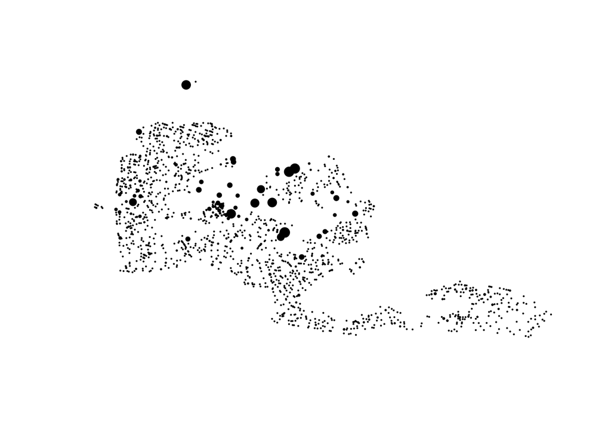

```r
library(sf)
map <- DVFOK %>% group_by(latitude, longitude) %>% count() %>% st_as_sf(coords=c("longitude","latitude"))

plot(map$geometry,cex=sqrt(map$n/20),pch=20,alpha=0.3)
```

```r
table(map$type)
```

```
< table of extent 0 >
```